# Lab 3B

Tree-based methods and SVM’s

2021

In this lab we classify the `spam` data again, but using different techniques than in the previous lab. For this lab you need the packages `kernlab`, `tree`, `randomForest`, `fastAdaboost`, `e1071` and `caret`.

# Training the models

To compare our results, we use the same training and test set. However, we do not bother to transform the features before we start. Why is this not necessary?

1. Make the same vector with indices for the training set as in the previous lab.

```r
data(spam)
set.seed(10)
train <- createDataPartition(y = spam$type, p = .75, list = FALSE)
```

## Tree

1. Grow a tree on the training set. Save the object as `train_tree`, and plot it.

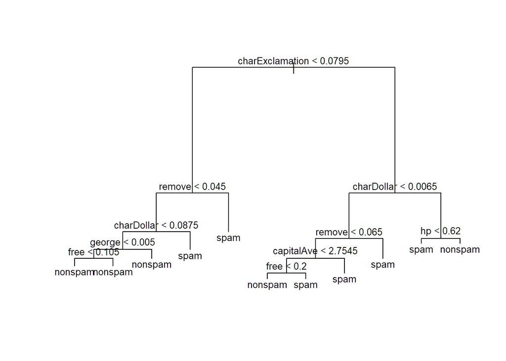

```r
train_tree <- tree(type ~ ., data = spam[train, ])
plot(train_tree)
text(train_tree, cex = 0.8)
```

2. The fitted may be overfitting. Before we can prune the tree we need to determine the optimal number of knots. Find out this number by performing cross-validation with the function `cv.tree()`.

```r
cv.tree(train_tree)
```

```
## $size
##  [1] 11 10  9  8  7  6  5  4  3  2  1
##
## $dev
##  [1] 1984.310 1992.391 2057.861 2140.672 2268.510 2447.188 2669.626 2747.279
##  [9] 3153.825 3411.551 4630.080
##
## $k
##  [1]       -Inf   47.91323   56.15141   70.43359   85.68119  140.57558
##  [7]  170.82537  191.46484  371.51350  435.13627 1205.73926
##
## $method
## [1] "deviance"
##
## attr(,"class")
## [1] "prune"         "tree.sequence"
```

4. Prune the tree using the optimal number of nodes from the cross-validation, and save the pruned tree object under an appropriate name.

```r
prune_tree <- prune.tree(train_tree, best = 11)
```

## Bagging/random forest

Both models can be trained with the function `randomForest()`. The only argument that needs to be changed is `mtry` (see the function’s help page). To learn about the importance of the features, set the argument `importance = TRUE`.

1. Train the bagging model, save its object as `train_bag`, and display and interpret its content.

```r
(train_bag <- randomForest(type ~ ., spam[train, ], importance = TRUE, mtry = 57))
```

```
##
## Call:
##  randomForest(formula = type ~ ., data = spam[train, ], importance = TRUE,      mtry = 57)
##                Type of random forest: classification
##                      Number of trees: 500
## No. of variables tried at each split: 57
##
##         OOB estimate of  error rate: 5.53%
## Confusion matrix:
##         nonspam spam class.error
## nonspam    2008   83  0.03969393
## spam        108 1252  0.07941176
```

```r
(train_rf  <- randomForest(type ~ ., spam[train, ], importance = TRUE))
```

```
##
## Call:
##  randomForest(formula = type ~ ., data = spam[train, ], importance = TRUE)
##                Type of random forest: classification
##                      Number of trees: 500
## No. of variables tried at each split: 7
##
##         OOB estimate of  error rate: 4.81%
## Confusion matrix:
##         nonspam spam class.error
## nonspam    2025   66  0.03156385
## spam        100 1260  0.07352941
```

3. Display the variable importance plots of both objects for the 10 most important predictors, and interpret.

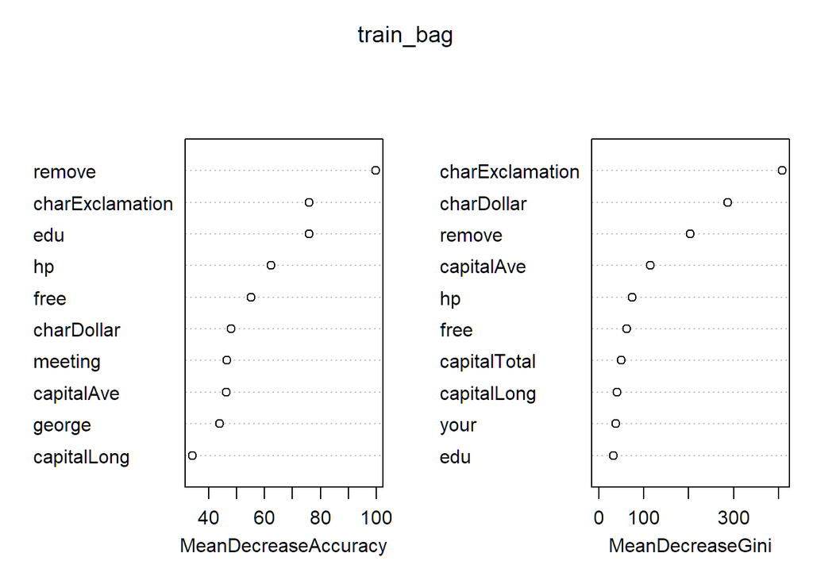

```r
varImpPlot(train_bag, n.var = 10)
```

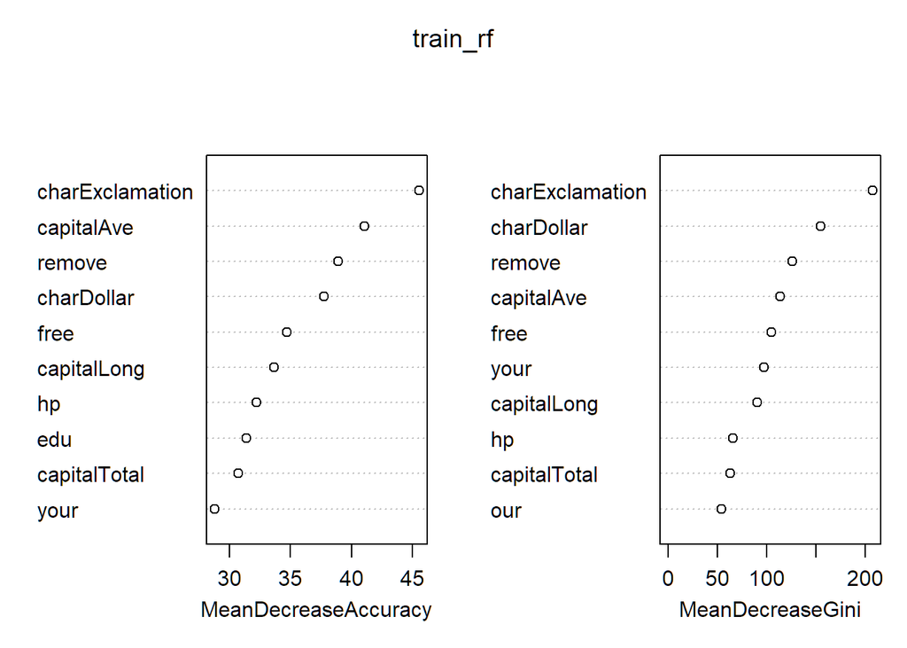

```r
varImpPlot(train_rf, n.var = 10)
```

## Boosting

For boosting we use the function `adaboost()` (check out the help page for this function). The function has the hyperparameter `nIter`, which is the number of weak learners that will be used. Remember that too few learners might lead to underfitting, and too many to overfitting. So, we will have to determine the optimal value of `nIter` with cross-validation. If we use the function `train()` for this, we need to specify, aside `formula` and `data`, the arguments `method = adaboost`, `tuneGrid = "Adaboots.M1", nIter = c(10, 25, 50))` and `trControl = trainControl(method = "cv", number = 5)`. Of course, you may also use different and/or more values for `nIter`. However, be aware that such changes may affect the computation time.

```r
train_boost <- train(type ~ .,
                     data       = spam[train, ],
                     method     = "adaboost",
                     tuneGrid   = expand.grid(method = "Adaboost.M1", nIter = c(10, 25, 50)),
                     trControl  = trainControl(method = "cv",
                                               number = 5)
)
```

3. Display and interpret the fitted boosting object.

```r
train_boost
```

```
## AdaBoost Classification Trees
##
## 3451 samples
##   57 predictor
##    2 classes: 'nonspam', 'spam'
##
## No pre-processing
## Resampling: Cross-Validated (5 fold)
## Summary of sample sizes: 2761, 2761, 2760, 2761, 2761
## Resampling results across tuning parameters:
##
##   nIter  Accuracy   Kappa
##   10     0.9400176  0.8748936
##   25     0.9478408  0.8907296
##   50     0.9472623  0.8896169
##
## Tuning parameter 'method' was held constant at a value of Adaboost.M1
## Accuracy was used to select the optimal model using the largest value.
## The final values used for the model were nIter = 25 and method = Adaboost.M1.
```

## Support Vector Machines

For training the support vector machine we the function `svm` of the package `e1071` (check its help page). Let’s train an extremely flexible one with a radial kernel. This kernel has a hyperparameter `cost` for which the optimal value has to be determined with cross-validation. This is done with the function `tune(method = svm, data = spam[train, ], kernel = "radial", ranges = list(cost = <sequence numbers>)`. The cost will be somewhere between 0 and 4.

1. Tune an SVM with radial kernel by cross-validating `cost`. Specify an appropriate sequence of values for `cost` to be cross-validated (warning: do not make the sequence too long, because the cross-validation takes quite some time). Save the object, and display and interpret its summary.

```r
train_svm  <- tune("svm", type ~ .,
                     data        = spam[train, ],
                     kernel      = "radial",
                     probability = TRUE,
                     ranges      = list(cost = c(1:4)))

summary(train_svm)
```

```
##
## Parameter tuning of 'svm':
##
## - sampling method: 10-fold cross validation
##
## - best parameters:
##  cost
##     2
##
## - best performance: 0.06433358
##
## - Detailed performance results:
##   cost      error  dispersion
## 1    1 0.06723214 0.011109490
## 2    2 0.06433358 0.008090203
## 3    3 0.06462260 0.007881940
## 4    4 0.06462344 0.008992412
```

```r
train_svm$best.model
```

```
##
## Call:
## best.tune(method = "svm", train.x = type ~ ., data = spam[train,
##     ], ranges = list(cost = c(1:4)), kernel = "radial", probability = TRUE)
##
##
## Parameters:
##    SVM-Type:  C-classification
##  SVM-Kernel:  radial
##        cost:  2
##
## Number of Support Vectors:  947
```

# Testing the models

As in the previous labs, we now evaluate the models by looking at misclassification test error.

1. Use the function `predict()` to obtain the class predictions on the test set for the pruned tree and the bagging, random forest, boosting and svm models.

```r
class_tree  <- predict(prune_tree,           spam[-train, ], type = "class")

class_bag   <- predict(train_bag,            spam[-train, ])

class_rf    <- predict(train_rf,             spam[-train, ])

class_boost <- predict(train_boost,          spam[-train, ])

class_svm   <- predict(train_svm$best.model, spam[-train, ])
```

```r
cf <- function(obs = spam[-train, 58], est)table(obs = obs, est = est)

(conf_tree <- cf(est = class_tree))
```

```
##          est
## obs       nonspam spam
##   nonspam     636   61
##   spam         61  392
```

```r
(conf_bag <- cf(est = class_bag))
```

```
##          est
## obs       nonspam spam
##   nonspam     670   27
##   spam         34  419
```

```r
(conf_rf <- cf(est = class_rf))
```

```
##          est
## obs       nonspam spam
##   nonspam     674   23
##   spam         30  423
```

```r
(conf_boost <- cf(est = class_boost))
```

```
##          est
## obs       nonspam spam
##   nonspam     668   29
##   spam         19  434
```

```r
(conf_svm <- cf(est = class_svm))
```

```
##          est
## obs       nonspam spam
##   nonspam     666   31
##   spam         48  405
```

```r
miscl <- function(x) 1 - sum(diag(x)) / sum(x)

data.frame(tree  = miscl(conf_tree),
           bag   = miscl(conf_bag),
           rf    = miscl(conf_rf),
           boost = miscl(conf_boost),
           svm   = miscl(conf_svm)) %>%
  round(4)
```

```
##     tree   bag     rf  boost    svm
## 1 0.1061 0.053 0.0461 0.0417 0.0687
```